# Optimizing Convolutional Neural Networks: An Iterative Approach to Hyperparameter Tuning for Image Classification

## Abstract

This tutorial presents an iterative approach to developing and optimizing a Convolutional Neural Network (CNN) for image classification. It emphasizes systematic hyperparameter tuning, including normalization, learning rate optimization using a learning rate finder, Cosine Annealing scheduling, and fine-tuned Stochastic Gradient Descent (SGD). Techniques such as dropout, batch normalization, and early stopping are applied to improve model performance. This guide aims to balance efficiency and accuracy in the training of deep learning models for robust image classification.

- Objectives
- The FashionMNIST Dataset
- Libraries
  - Normalization
  - Visualizing the loaded Data
- The CNN Fundamentals
- Basic CNN Model: Laying the Foundation
  - Early Stopping
  - Loss Function
  - Learning Rate Finder
  - Optimizer
  - Building Our Training and Validation Loop
  - Plotting the Loss and Accuracy
  - Evaluating the Loss and Accuracy of our Basic Model
  - Evaluating with the Test Data
  - Creating a Confusion Matrix
  - Visualizing Confusion Matrix (Basic))
  - GradCAM: Visualizing the Model in Action
  - Visualizing GradCAM (Basic))
- Deeper CNN Model: Enhancing Feature Extraction
  - Purpose of the Deeper CNN
  - Visualizing Confusion Matrix (Deeper))
  - Visualizing GradCAM (Deeper))
- The Advanced CNN: Optimizing Hyperparameters, Avoiding Overfitting, and Putting Everything Together
  - Data Augmentation
  - Optimizing the Optimizer
  - The Scheduler
  - Evaluating the Loss and Accuracy of our Advanced Model
  - Visualizing Confusion Matrix (Advanced))
  - Visualizing GradCAM (Advanced))
  - Comparing the metrics of each of my Models
- Comparison with Other Models
- Conclusion
- References

## Objectives

- Understand the importances of Data Pre-Processing with remedies such as Normalization and Data Augmentation and how it contributes to building the robustness of a CNN Model
- Defining a Basic CNN Model for Image Classification, that can dynamically change its batch size and other hyperparameters without the need of considering the new Learning Rate value with using a **Learning Rate Finder**
- Learn how to visualize different models and their respective performances using **GradCAM** & **Confusion Matrices**
- Iteratively improving on this Basic CNN model by implementing hyperparameter tuning techniques and regularization, and introducing new performance optimizations such as **Cosine Annealing**
- Learn how to analyze and compare the models performance using matplotlib

## The FashionMNIST Dataset

- In this tutorial, we will train each of our models using the **FashionMNIST Dataset**.
- FashionMNIST is a well-renowned starting point for building a CNN, offering a balance between **computation speed** and **complexity**:
  - **Computation speed**: Each image is a 28×28 grayscale representation of clothing items (e.g., shoes, shirts), requiring fewer channels than larger image datasets, leading to faster training times.
  - **Complexity**: Despite its small size, each image label has unique attributes that differentiate it from others. This allows a basic model to achieve reasonable accuracy, while also exposing its limitations, making it an excellent dataset for iteratively improving CNN architectures.

For these reason, I have chosen to use this model to build and improve on making a CNN through advanced techniques that will be noticed through this dataset

## Libraries

- This tutorial will involve several libraries in order to achieve our end goal, which I have split by indentation based on its purpose

```python
# Creating models and hyperparameter optimization
import torch
import torch.nn as nn
import torch.optim as optim
from torch.optim.lr_scheduler import CosineAnnealingLR
import torch.nn.functional as F

# Importing and transforming the dataset (i.e. scaling and normalization)
from torchvision import transforms, models, datasets

# Datasets - Loading, combining, splitting, and other utilities
from torch.utils.data import ConcatDataset, DataLoader, random_split, Subset, Dataset
from sklearn.model_selection import train_test_split

# For numerical operations and array handling
import numpy as np

# Plotting results
import matplotlib.pyplot as plt
import seaborn as sns

# Organizing return values together
from collections import namedtuple

# A Learning rate finder (Will be discussed further later)
from fastai.vision.all import *
from fastai.data.core import DataLoaders
from fastai.optimizer import OptimWrapper

from functools import partial

# Track the time that models take to train
import time

# Plotting GradCAM
from pytorch_grad_cam import GradCAM
from pytorch_grad_cam.utils.model_targets import ClassifierOutputTarget

# Plotting Confusion Matrix
from sklearn.metrics import confusion_matrix
```

## Cuda

- Cuda is a NVIDIA exclusive technology that allows you to process tensors on your GPU
- Normally, the CPU will do this, but as GPUs are much quicker at processing tensors due to parallel processing and the abilioty to process complex maths significatly faster
- So its very beneficial to use if you have the computing hardware for it as it saves a lot of training time

```python
device = torch.device("cuda" if torch.cuda.is_available() else "cpu")
print(f"Device: {device}")
```

```
Device: cuda
```

## Data Pre-Processing

- For starters, we must have each image serialized as a tensor in order for pytorch to process it correctly
- Initially, our dataset will contain greyscale images each with values [0,255]
  - `ToTensor()` will convert this into a pytorch tensor, whilst scaling the values to [0.0, 1.0]

```python
transform = transforms.Compose([
    transforms.ToTensor() # Convert image array into a pytorch tensor
])
```

Now we have the required transformations, we can get the training and validation data by loading the FashionMNIST Dataset [18] and apply this transformation to it

```python
train_val_dataset = datasets.FashionMNIST(root="./data", train=True, transform=transform, download=True)
test_dataset = datasets.FashionMNIST(root="./data", train=False, transform=transform, download=True)
```

We can also view the classes here

```python
class_names = train_val_dataset.classes
print(f"Classes: {class_names}")
```

```
Classes: ['T-shirt/top', 'Trouser', 'Pullover', 'Dress', 'Coat', 'Sandal', 'Shirt', 'Sneaker', 'Bag', 'Ankle boot']
```

Next, we need to split the training and validation data into a 80/20 split

```python
train_size = int(0.8 * len(train_val_dataset))  # 80% training
val_size = len(train_val_dataset) - train_size  # 20% validation
train_dataset, val_dataset = random_split(train_val_dataset, [train_size, val_size]) #80/20 split between Train and Val Dataset

print(f"Training samples: {len(train_dataset)}")
print(f"Validation samples: {len(val_dataset)}")
print(f"Test samples: {len(test_dataset)}")
```

```
Training samples: 48000
Validation samples: 12000
Test samples: 10000
```

- I will be using a batch size of 64 in this tutorial
  - This means that the model will process 64 tensors at a time before a single weight update
- This value can be adjusted, but its important to consider that the learning rate will also need to be adjusted in conjunction with it [19]
  - Fortunately, this tutorial uses a Learning Rate finder which takes the batch size and many other parameters into consideration, so its not a concern here but may be in other notebooks

```python
batch_size=64
```

We now need to create the loaders for train, val and test respectively, which we will use to iterate through batches when training our model

```python
train_loader = DataLoader(train_dataset, batch_size=batch_size, num_workers=4, shuffle=True)
val_loader = DataLoader(val_dataset, batch_size=batch_size, num_workers=4, shuffle=False)
test_loader = DataLoader(test_dataset, batch_size=batch_size, num_workers=4, shuffle=False)

print(f"Training batches: {len(train_loader)}")
print(f"Validation batches: {len(val_loader)}")
print(f"Test batches: {len(test_loader)}")
```

```
Training batches: 750
Validation batches: 188
Test batches: 157
```

### Normalization

- As discussed above, When we apply `transforms.ToTensor()` in PyTorch, it automatically scales these pixel values to a range between 0.0 and 1.0
- However, even with this scaling, some pixels might still have disproportionately high or low values relative to others. This can lead to imbalances during training, where the model gives undue importance to certain features purely because of their value ranges, not their actual significance
- That’s where **normalization** comes in!
  - Normalization adjusts the pixel values to have a **mean of 0** and a **standard deviation of 1**, based on the dataset’s overall statistics (its mean and standard deviation)
  - This ensures that the input data is centered and scaled, helping the model to:
    - Train faster
    - Improve convergence
    - Prevent certain neurons from dominating due to larger input values.
- Since every dataset has its own unique distribution of pixel values, we calculate the **mean** and **standard deviation** specifically for the FashionMNIST dataset, as shown in the code below [16]:

```python
n_samples_seen = 0.  # Total number of samples processed
mean = 0  # Accumulator for the mean
std = 0   # Accumulator for the standard deviation

# Iterate over batches in the train_loader
for train_batch, train_target in train_loader:
    batch_size = train_batch.shape[0]  # Current batch size

    # Flatten each image to a vector (batch_size, num_pixels)
    train_batch = train_batch.view(batch_size, -1)

    # Compute mean for each sample in the batch
    batch_mean = torch.mean(train_batch, dim=1)

    # Compute std for each sample in the batch
    batch_std = torch.sqrt(
        torch.mean((train_batch - batch_mean[:, None]) ** 2, dim=1)
    )

    # Accumulate sums of batch means and stds
    mean += torch.sum(batch_mean, dim=0)
    std += torch.sum(batch_std, dim=0)

    # Update the total number of samples processed
    n_samples_seen += batch_size

# Compute averages to get mean and std
mean /= n_samples_seen
std /= n_samples_seen

print(f'Mean: {mean:.4f}')
print(f'Std: {std:.4f}')
```

```
Mean: 0.2861
Std: 0.3203
```

We can then overwrite the original transform by adding this normalization function

```python
transform = transforms.Compose([
    transforms.ToTensor(),
    transforms.Normalize((mean,), (std,))
])
```

But now since we have overriden the transform, we will need to reload the dataset

```python
train_val_dataset = datasets.FashionMNIST(root="./data", train=True, transform=transform, download=True)
test_dataset = datasets.FashionMNIST(root="./data", train=False, transform=transform, download=True)

train_size = int(0.8 * len(train_val_dataset))
val_size = len(train_val_dataset) - train_size
train_dataset, val_dataset = random_split(train_val_dataset, [train_size, val_size])

train_loader = DataLoader(train_dataset, batch_size=batch_size, num_workers=0, shuffle=True)
val_loader = DataLoader(val_dataset, batch_size=batch_size, num_workers=0, shuffle=False)
test_loader = DataLoader(test_dataset, batch_size=batch_size, num_workers=0, shuffle=False)
```

### Visualizing the loaded Data

After reloading and normalizing the dataset, we can view some of the images from the DataSet here

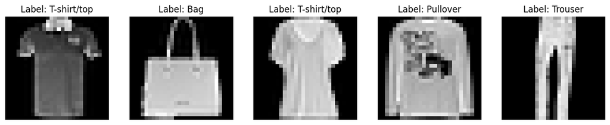

```python
# Denormalization helper function
def denormalize(tensor, mean=mean, std=std):
    return tensor * std + mean

# Get the first 5 samples
images, labels = zip(*[train_dataset[i] for i in range(5)])

# Setup the plot
fig, axes = plt.subplots(1, 5, figsize=(15, 3))

for i, ax in enumerate(axes):
    # Images are tensors: [1, 28, 28]

    # Denormalize and remove channel dimension
    image = denormalize(images[i].squeeze())

    # Convert to numpy for plotting
    ax.imshow(image.numpy(), cmap='gray')
    ax.set_title(f"Label: {class_names[labels[i]]}")
    ax.axis('off')

plt.show()
```

## The CNN Fundamentals

- In this section, we will be building and training on a Basic Model, with focus on key concepts that act as the backbone of any CNN
- This will include:
  - Channel Size
  - Learning Rate Tuning
  - Early Stopping
- The aim with the Basic Model training is to understand the basics of how forward feeding and weight modifications occur
- As stated in the introduction, we will be using a CNN model to classify the dataset images

### Why CNN?

- CNNs have many properties that differ from a classic ANN that make it better suited to image classification, and offer more performance and scalability through the following ways [1]:
  - Local Feature Learning: CNNs Focus on local regions of the image, one area at a time through convolutional layers
    - Can capture more meaningful patterns
    - Significnalty more efficient than feeding the entire image into the model at once, as it drastically reduces the parameters
  - Hierarchical Feature Learning: CNNs are built with multiple layers of abstraction
    - Early layers capture low-level features (such as edges and textures), while deeper layers learn more complex, high-level features (such as shapes and entire objects)

## Basic CNN Model: Laying the Foundation

For our basic model, we will discuss the essentials of any CNN, and build upon this baseline in our later models to slowly increase the models accuracy

To understand this baseline on building a solid CNN structure, I used a tutorial made by Greg Hogg, which can be found on YouTube [2]

Each CNN model in PyTorch requires **two** essential functions:

1. `__init__()`
2. `forward()`

### **1.** `__init__()` – *Initialize the Layers*

The `__init__()` function is similar to a **constructor** in other programming languages.

In this function, we **define the building blocks** (or layers) of our network. These layers are **not executed immediately**; we’re just setting up the blueprint for our model.

In our Basic Model, it consists of one of every essential layer for most CNNs, which are:

- A **Convolutional Layer (`conv1`)**:
  - In this layer, a small square-shaped filter (also called a kernel) slides across the image.
  - At each position, the filter looks at a small patch of the image and performs a mathematical operation:
    - It **multiplies** each pixel value by a corresponding weight in the filter,
    - Then **adds them all up** into a single number.
  - This process **summarizes** the information in that region, detecting meaningful patterns like edges, textures, or other features.
    - This summarization is known as a **feature map**

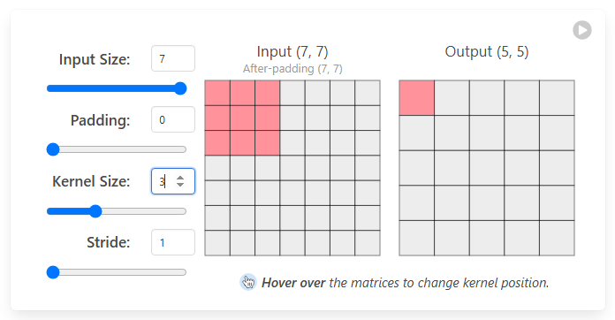

  - The conv layer takes several arguments, including:
    - `in_channels`: This is the **number of input channels** the layer expects.
      - In the **first convolutional layer**, `in_channels` matches the **number of channels in your input image**:
        - `1` for **grayscale images** (each pixel has 1 value) (So this is what we will use as FashionMNIST is a greyscale dataset).
        - `3` for **color images (RGB)** (each pixel has 3 values: red, green, and blue).
      - In **deeper layers**, `in_channels` will usually be equal to the `out_channels` of the **previous** convolutional layer.
        - For example: If your first conv layer outputs **8 feature maps** (`out_channels=8`), the **next** conv layer would have `in_channels=8`.
    - `out_channels`: This defines the **number of feature maps**, the layer will produce
      - Each feature map is designed to extract certain **features** or **patterns** from the input image.
        - And when combined, these feature maps give the network a **richer and more detailed understanding** of the image.
          - For example:  
            - One feature map might highlight certain textures. - Another might detect vertical edges.  
            - etc.

### **2.** `forward()` – *Propagating through the layers*

- The `forward()` function defines each of the steps of walking through the model
- It's the **actual computation** from input to output. Every time we run our model on some input data, PyTorch calls this method.
- When defining a forward function, its important that we add some sort of **activation function** to it
  - This introduces **non-linearity** to the model
    - Without it, the model would essentially be performing a linear transformation, regardless of the number of layers you add, meaning it wouldnt be able to extract complicated relationships
  - The activation function we will be using in our model is the `ReLU` function

Referenced from [3]

```python
class BasicCNN(nn.Module):
    def __init__(self, input_shape=(1, 28, 28), num_classes=10):
        super(BasicCNN, self).__init__()

        # Convolutional Layer
        # Input: 1-channel grayscale images of size 28x28 -> Output: 8 feature maps of size 24x24 (no padding, kernel 5x5, stride 1)
        self.conv1 = nn.Conv2d(in_channels=1, out_channels=8, kernel_size=5, padding=0, stride=1)

        # Pooling layer
        # Input: 8 feature maps of size 24x24 -> Output: 8 feature maps of size 12x12 (halves spatial dimensions)
        self.pool = nn.MaxPool2d(2, 2)

        # Automatically calculate flattened size
        self.flattened_size = self._get_flattened_size(input_shape)

        # Fully connected layer:
        # Input: Flattened feature vector of size `self.flattened_size` -> Output: `num_classes` logits (1 for each class).
        self.fc1 = nn.Linear(self.flattened_size, num_classes)


    # Dummy pass through conv + pool to calculate output size
    def _get_flattened_size(self, input_shape):
        with torch.no_grad():
            x = torch.zeros(1, *input_shape)
            x = F.relu(self.conv1(x))  # Conv
            x = self.pool(x) # Pool
            flattened_size = x.numel()  # Flatten the features
        return flattened_size

    def forward(self, x):
        # Layer 1
        x = F.relu(self.conv1(x))
        x = self.pool(x)

        # Layer 2
        x = x.view(-1, self.flattened_size)  # Flatten

        # Layer 3
        x = self.fc1(x)  # Output logits
        return x  # Return logits

# Intantiate the Model
basic_model = BasicCNN().to(device)
print(basic_model)
```

```
BasicCNN(
  (conv1): Conv2d(1, 8, kernel_size=(5, 5), stride=(1, 1))
  (pool): MaxPool2d(kernel_size=2, stride=2, padding=0, dilation=1, ceil_mode=False)
  (fc1): Linear(in_features=1152, out_features=10, bias=True)
)
```

We will define some layouts for the return values later on so they are easier to interpret

```python
TrainMetrics = namedtuple("TrainMetrics", ["losses", "accuracies"]) # Contain all train metrics
ValidationMetrics = namedtuple("ValidationMetrics", ["losses", "accuracies", "best_accuracy"]) # Contain all validation metrics
TimeMetrics = namedtuple("TimeMetrics", ["epochs", "total"]) # Contain all time based metrics

ModelMetrics = namedtuple("ModelMetrics", ["train", "val", "time"]) # Container for all 3
```

### Early Stopping

- One of the most common challenges faced when training models in machine learning is overfitting
  - This is when the model gets too accustomed to the training data and is no longer able to adapt to unseen (validation/testing) data as reliably
    - This usually happens after several epochs
  - To combat this, we can use a technique known as early stopping, where we can actively monitor the model's performance on unseen data and stop the training process early if overfitting starts to occur
- To implement this, we first design a class so we can actively keep track of the model's performance and continuously update this class throughout the training cycle
  - If the class detects that the model has started overfitting, we can then halt the training process to prevent any unnecessary further accuracy loss

The properties of this class are:

- `patience`: How many epochs to wait before stopping
- `delta`: Minimum improvement needed to reset the counter
- `counter`: The number of epochs it's been since the model hasn't started improving
- `best_val_loss`: The lowest recorded validation loss to compare to when detecting if the model is improving

There is another reason I have decided to implement Early Stopping in this tutorial, which is due to our Learning Rate Finder that we'll be implementing and discussing later.

Referenced from [4]

```python
class EarlyStopping:
    def __init__(self, patience=5, delta=0):
        self.patience = patience  # How many epochs to wait before stopping
        self.delta = delta  # Minimum improvement needed to reset counter
        self.counter = 0 # Counts the number of epochs its been since last improvement
        self.best_val_loss = None # Current lowest Validation loss
        self.early_stop = False

    def __call__(self, val_loss):
        if self.best_val_loss is None:
            self.best_val_loss = val_loss
        elif val_loss < self.best_val_loss - self.delta:
            # Improvement
            self.best_val_loss = val_loss
            self.counter = 0
        else:
            # No improvement
            self.counter += 1
            print(f"No improvement in val_loss for {self.counter} epoch(s)")
            if self.counter >= self.patience:
                self.early_stop = True
```

We will set a starting point for the number of epochs here that likely wont be passed as Early Stopping will likely detect overfitting before this in the early models

```python
num_epochs = 100
```

### Loss Function

- If we zoom into our `forward()` function here:

```
# Layer 3
x = self.fc1(x)  # Output logits
return x  # Return logits
```

You'll notice that we haven't provided a `softmax` activation function at the end

- This means that the output `x` is a vector or raw scores, know as **logits**
  - These logits are not probabilities, they can be any number ranging from + to - infinity
    - Though since we'll be using the `CrossEntropyLoss()` function, we dont need to worry about converting these logits in the forward() function as it already applies the softmax to these values internally

Referenced from: [2]

```python
loss_fn = nn.CrossEntropyLoss()
```

### Learning Rate Finder

- The idea was inspired by this tutorial I found online [5], and after further research [6], I concluded that using a function to automatically find an effective learning rate that minimizes error and improves training performance would be a valuable addition to training my models
- Finding an optimal learning rate is paramount for any DNN model such as a CNN as:
  - If your learning rate is set too low, although the progress will be closer every single epoch, the training process would be too slow and your model would take significantly longer to converge
  - If your learning rate is too high, the adjustments may cause it to "jump" over the minima, preventing proper convergence.

  So it's important to choose a learning rate that is "just right" [7]

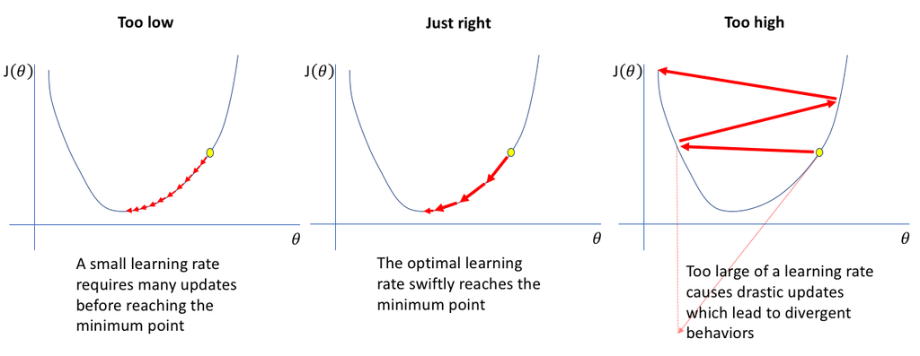

- From researching different libraries and techniques to having a learning rate finder, I concluded to using **FastAI**'s learning rate finder [8]
  - FastAI offer an extremely intuitive way to get the learning rate through a simple `learner.lr_find()` function, which takes some of your configured hyperparamers and, through gradual testing of different learning rates and its responses, comes back with 4 learning rate values, that you can you can use and test on your training loop
  - It also has built in weight preservation and restoration so theres no need for concern of having to reset, or recoever the models weights before the function call as this is all handled by FastAI
- Out of the 4 learning rate values that are produced, "valley" is seen as generally the most effective for most models as its the value where the learning rate is still low enough to be stable, but high enough to benefit from training: around 2/3 in. [9]
- In the `find_lr` function, I will return two lr's:
  - `lr_valley`: This is the standard learning rate for the model set for the optimizer provided there is no scheduler set
  - `lr_valley*10`: This is used as the starting learning rate for the optimizer, where the prior return is used as the finishing learning rate for a learning rate scheduling (will be discussed later)

We will define a `find_lr()` function that takes the model, the optimizer class (e.g. Adam or SGD) and some arguments for that optimizer use these parameters (along with the dataloader collection from earler), to pass into the FastAI's learner, which will find the optimal lr for us, which we can then return after

```python
def find_lr(model, optimizer_class, opt_kwargs=None, num_it=100):
    if opt_kwargs is None:
        opt_kwargs = {}

    loss_fn = nn.CrossEntropyLoss()

    opt_func = partial(OptimWrapper, opt=optimizer_class, **opt_kwargs)

    learn = Learner(dls, model, loss_func=loss_fn, opt_func=opt_func, metrics=error_rate)

    _, _, lr_valley, lr_slide  = learn.lr_find(num_it=num_it, suggest_funcs=(minimum, steep, valley, slide))

    return lr_valley, lr_valley*10
```

Since FastAI requires a specific collection of our data loaders, I will define that here

```python
dls = DataLoaders(train_loader, val_loader)
```

Now we have defined all the required parameters for the `find_lr()`, we can call it here and get the optimal learning rate for our model, with our chosen optimizer, (which will be discussed further below)

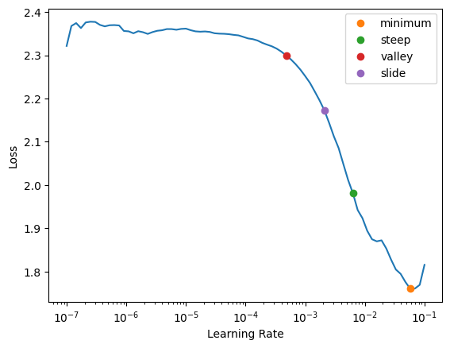

```python
lr, _, = find_lr(basic_model, optimizer_class=optim.Adam)
```

The red dot on the graph shows the `valley`. Which will be our learning rate when training this model.

### Optimizer

There are many different optimizers available in PyTorch, such as **Adam**, **AdamW**, and **SGD**, each with their own strengths.

- An Optimizers aim is to make an adjustment to each of the weights using the **gradient** calculated from back propagation and the **learning rate**
- Despite all serving the same purpose, each learning rate achieves their goal in different ways, and depending on your use case, different optimizers will be better or worse

However, for this project, I’ve chosen to start off with using **Adam** as my optiomizer of choice due to its ability to reach good convergances completely out-of-the-box, which is ideal for our Basic Model, which limits in optimizations and hyperparameter tuning

```python
optimizer = optim.Adam(basic_model.parameters(), lr=lr)
```

### Building our Training and Validation Loop

- We have now prepared everything we need to train and validate our model, so the next step is to build the training and validation loop
- We will run these training and validation loops in the `train_model()` function
  - This function will essentially run the training loop `train()`, and then the validation loop `validation()`, for the number of epochs specified
  - Our function will also keep track of train & val **loss/accuracy** through appending to a list for plotting this data for comparison later on
  - Additionally, it uses **early stopping** to halt training when the model stops improving on the validation data.
  - The function logs the **duration** of each epoch to help monitor performance.
- `train()`:
  - This function trains the model for **one epoch**, performing a **forward pass** on each batch of training data.
  - It loops through each batch in the `train_loader`:
    - Calculates the **predictions** from the model.
    - Computes the **loss** between the predictions and actual labels.
    - Performs **backpropagation** to calculate gradients.
    - Updates the model's weights using the **optimizer**, based on the loss.
  - It tracks the **total loss** and **accuracy** across the entire epoch.
- `validate()`:
  - This function evaluates the model's performance on the **validation dataset** without updating the weights.
  - It loops through each batch in the `val_loader`:
    - Runs a **forward pass** to get predictions.
    - Calculates the **loss** between predictions and actual labels.
  - During validation, gradient calculations are disabled using `torch.no_grad()` to **improve efficiency** and **reduce memory usage**.
  - It tracks the **total loss** and **accuracy** across the validation dataset and returns the averages for both.

```python
def train(model, train_loader, loss_fn, optimizer, scheduler):
    model.train()  # Set model to training mode

    # Metrics
    running_loss = 0.0  # Accumulate total loss for the epoch
    running_correct = 0  # Number of correct predictions (For accuracy)
    total_samples = 0

    for inputs, labels in train_loader:
        # Move data to the same device as the model
        inputs, labels = inputs.to(device), labels.to(device)

        optimizer.zero_grad() # Clear old gradients

        outputs = model(inputs) # Forward Pass
        loss = loss_fn(outputs, labels) # Compute the loss
        loss.backward() # Compute gradients
        optimizer.step() # Update weights & biases

        # Update metrics
        running_loss += loss.item()
        preds = outputs.argmax(dim=1)
        running_correct += (preds == labels).sum().item()
        total_samples += labels.size(0)

    # Step the scheduler once per epoch
    if scheduler is not None:
        scheduler.step()

    # Compute averages for the training set
    avg_loss = running_loss / len(train_loader)
    avg_accuracy = (running_correct / total_samples) * 100

    return avg_loss, avg_accuracy

def validate(model, val_loader, loss_fn):
    model.eval()  # Set model to evaluation mode

    # Metrics
    running_loss = 0.0
    running_correct = 0
    total_samples = 0

    with torch.no_grad():  # Disable gradient computation for validation
        for inputs, labels in val_loader:
            # Move data to the same device as the model
            inputs, labels = inputs.to(device), labels.to(device)

            outputs = model(inputs) # Forward Pass
            loss = loss_fn(outputs, labels) # Compute Loss

            # Update metrics
            running_loss += loss.item()
            preds = outputs.argmax(dim=1)
            running_correct += (preds == labels).sum().item()
            total_samples += labels.size(0)

    # Compute averages for the validation set
    avg_loss = running_loss / len(val_loader)
    avg_accuracy = (running_correct / total_samples) * 100

    return avg_loss, avg_accuracy

def train_model(model, train_loader, val_loader, loss_fn, optimizer, scheduler, num_epochs, use_early_stopping=True):
    # Lists to accumulate metrics
    train_epoch_losses = []
    train_epoch_accuracies = []
    val_epoch_losses = []
    val_epoch_accuracies = []
    epoch_durations = []

    best_val_accuracy = 0.0

    early_stopping = EarlyStopping()

    # Ensure model is on the correct device
    model.to(device)

    # Start the total training timer
    training_start_time = time.time()

    # Iterate through epochs
    for epoch in range(num_epochs):
        # Start timing this epoch
        start_time = time.time()

        # Train and Validate
        train_loss, train_accuracy = train(model, train_loader, loss_fn, optimizer, scheduler)
        val_loss, val_accuracy = validate(model, val_loader, loss_fn)

        # End timing this epoch
        end_time = time.time()

        # Compute epoch duration
        epoch_duration = end_time - start_time
        epoch_durations.append(epoch_duration)

        if val_accuracy > best_val_accuracy:
            best_val_accuracy = val_accuracy

        # Collect metrics
        train_epoch_losses.append(train_loss)
        train_epoch_accuracies.append(train_accuracy)
        val_epoch_losses.append(val_loss)
        val_epoch_accuracies.append(val_accuracy)

        print(f"Epoch {epoch + 1}/{num_epochs}: "
              f"Train Loss = {train_loss:.4f}, Train Accuracy = {train_accuracy:.2f}% | "
              f"Val Loss = {val_loss:.4f}, Val Accuracy = {val_accuracy:.2f}%")
        print(f"Epoch duration: {epoch_duration:.2f} seconds")

        # Early stopping check
        if use_early_stopping:
            early_stopping(val_loss)
            if early_stopping.early_stop:
                print(f"Stopping at epoch {epoch + 1}")
                break

    training_end_time = time.time() # Record the time time of the training
    total_duration = training_end_time - training_start_time # Gets the time it took to train the model

    print(f"Total Duration: {total_duration:.2f} seconds")

    # Prepare namedtuple returns
    train_metrics = TrainMetrics(losses=train_epoch_losses, accuracies=train_epoch_accuracies)

    val_metrics = ValidationMetrics(losses=val_epoch_losses, accuracies=val_epoch_accuracies,best_accuracy=best_val_accuracy)

    time_metrics = TimeMetrics(epochs=epoch_durations, total=total_duration)

    # Return namedtuples
    return ModelMetrics(train=train_metrics, val=val_metrics, time=time_metrics)
```

We can now call the `train_model()` function on our model

```python
basic_metrics = train_model(basic_model, train_loader, val_loader, loss_fn, optimizer, None, num_epochs)
```

```
Epoch duration: 14.25 seconds
Epoch duration: 14.23 seconds
Epoch duration: 14.61 seconds
Epoch duration: 16.27 seconds
Epoch duration: 14.19 seconds
Epoch duration: 14.32 seconds
Epoch duration: 15.20 seconds
No improvement in val_loss for 1 epoch(s)
Epoch duration: 14.59 seconds
Epoch duration: 14.58 seconds
No improvement in val_loss for 1 epoch(s)
Epoch duration: 14.22 seconds
Epoch duration: 14.12 seconds
No improvement in val_loss for 1 epoch(s)
Epoch duration: 14.39 seconds
Epoch duration: 14.53 seconds
No improvement in val_loss for 1 epoch(s)
Epoch duration: 14.01 seconds
Epoch duration: 14.29 seconds
No improvement in val_loss for 1 epoch(s)
Epoch duration: 14.21 seconds
No improvement in val_loss for 2 epoch(s)
Epoch duration: 14.21 seconds
Epoch duration: 14.99 seconds
No improvement in val_loss for 1 epoch(s)
Epoch duration: 14.15 seconds
No improvement in val_loss for 2 epoch(s)
Epoch duration: 14.22 seconds
No improvement in val_loss for 3 epoch(s)
Epoch duration: 14.14 seconds
No improvement in val_loss for 4 epoch(s)
Epoch duration: 14.22 seconds
No improvement in val_loss for 5 epoch(s)
Stopping at epoch 22
Total Duration: 317.94 seconds
```

### Plotting the Loss and Accuracy

- Since we recorded the loss and accuracy of the training and validation data over every epoch during our `train_model()` function, we can define a function which will take these two metrics and plot this data on their own seperate graphs

```python
def plot_metric(train_metric, val_metric, metric_name="Metric"):
    plt.figure(figsize=(10, 5))
    plt.plot(train_metric, label=f"Training {metric_name}")
    plt.plot(val_metric, label=f"Validation {metric_name}")

    plt.xlabel("Epochs")
    plt.ylabel(metric_name)
    plt.title(f"{metric_name} Over Epochs")
    plt.legend()
    plt.grid(True)
    plt.show()
```

### Evaluating the Loss and Accuracy of our Basic Model

We can then call the functions, passing in the appropriate lists and parameters

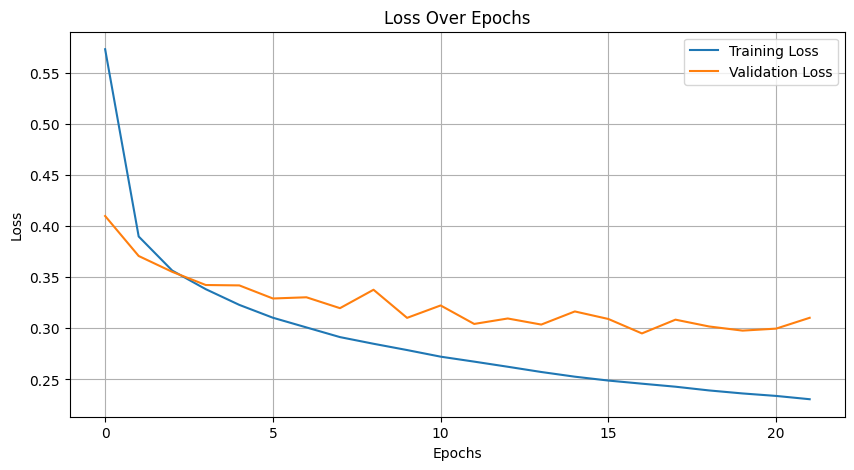

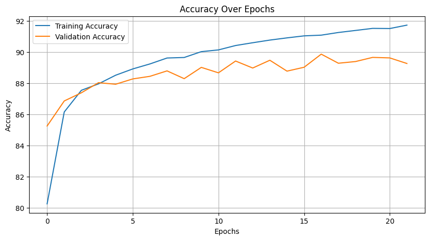

```python
# Plot losses
plot_metric(basic_metrics.train.losses, basic_metrics.val.losses, metric_name="Loss")

# Plot accuracies
plot_metric(basic_metrics.train.accuracies, basic_metrics.val.accuracies, metric_name="Accuracy")
```

#### Training

- As observed from our two graphs, the basic models training loss steadily decreases, whilst the accuracy steadily increases
- It starts off with a very high loss, with a corresponding very low accuracy, but within the first few epochs, it will able to take a sharp level of improvement, eventually levelling out at approximatley 91% accuracy
- However, it is limited in its ability to improve further in the final 10% of accuracy due to its shallow architecture
  - Having only one convolutional layer and limited channels makes it less capable of capturing more complex patterns that differentiate between similar images.

#### Validation

- Validation performance fluctuated throughout the training cycle, particularly after the initial few epochs.
- While it showed some early improvement, it plateaued and became inconsistent, indicating the model is prone to **overfitting** and struggles to generalize to unseen data.

### Evaluating with the Test Data

- Although we already have validation data through the validation dataset, it is important to also include another layer of validation data: the **test dataset**, to evaluate the model's performance on **fully unseen and unbiased data**.
- The **validation set** is typically used during training to monitor performance, tune hyperparameters, and prevent overfitting.
  - Because of this, the model may **indirectly** become optimized for the validation set, introducing potential bias.
- The **test set** remains untouched throughout the entire training and validation process. It provides a **final, objective assessment** of how well the model generalizes to new data it has **never seen** before.
- Testing on this separate dataset gives a more **realistic estimate** of how the model would perform in a **real-world scenario**.
- In this project, the test dataset was loaded independently (using `train=False` in torchvision datasets) to ensure it represents **truly unseen data**, distinct from the validation data split.

```python
Predictions = namedtuple('Predictions', ['actual', 'predicted'])
```

- We can then create a new function called `evalutate_model()` which, very simillarly to the validation loop, uses `torch.no_grad()`, followed by iterating through each batch and gathering each of the correct and incorrect predictions and appending them to the list
- At the end of the loop, we can then calculate the final accuracy, followed by the list of predictions

```python
def evaluate_model(model, dataloader):
    model.to(device)
    model.eval()

    total = 0
    correct = 0

    preds = []      # stores all predicted labels
    actuals = []    # stores all true labels (was previously overwritten)

    with torch.no_grad(): # Disable gradient computation (faster and saves memory)
        for inputs, labels in dataloader:
            # Move data to the same device as the model
            inputs, labels = inputs.to(device), labels.to(device).long()

            outputs = model(inputs) # Forward Pass
            predicted = torch.argmax(outputs, dim=1) # Get predicted class indices

            total += labels.size(0) # Increment total samples
            correct += (predicted == labels).sum().item() # Increment correct predictions

            # Convert back into cpu for numpy
            preds.extend(predicted.cpu().numpy())
            actuals.extend(labels.cpu().numpy())


    accuracy = 100 * correct / total

    predictions = Predictions(actual=actuals, predicted=preds)

    return accuracy, predictions
```

We can now run and return the final test accuracy

```python
basic_test_accuracy, basic_predictions = evaluate_model(basic_model, test_loader)

print(f"Accuracy on Test Set: {basic_test_accuracy:.2f}%")
```

```
Accuracy on Test Set: 88.96%
```

As shown, the test accuracy has the same issues as the Validation Accuracy, which is the inability to generalize what its learnt

### Creating a Confusion Matrix

- These test and validation metrics discussed above are useful
  - However, it is also equally important to know **where** the model is predicting incorrectly, and not just a summary of how many it gets right and wrong
- Using the predictions captured above, we can pass these predictions into a confusion matrix to observe where exactly the model is failing
- For example, is it failing to distinguish between T-Shirts and Pullovers? etc.
- Using this matrix, we can explain the models limitations in correspondance with its limited model density and how we can improve it later on in our code

```python
def plot_confusion_matrix(predictions):
    cm = confusion_matrix(predictions.actual, predictions.predicted)

    cm = cm.astype('float') / cm.sum(axis=1)[:, np.newaxis] # Relative between each cell

    plt.figure(figsize=(10, 8))
    sns.heatmap(cm, annot=True, fmt='.2f',
                cmap='YlGnBu',  # Blue to Yellow (Green inbetween)
                xticklabels=class_names, yticklabels=class_names)

    plt.title('Confusion Matrix (Accuracy)')
    plt.xlabel('Predicted Label')
    plt.ylabel('True Label')
    plt.show()
```

### Visualizing Confusion Matrix (Basic)

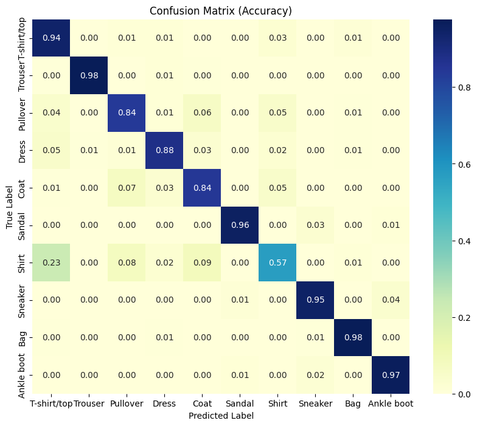

```python
plot_confusion_matrix(basic_predictions)
```

Our model overall performs reasonably adequately, though struggles with distinguishing between certain images, particularly between different types of Shirts

- So from this, we can observe that in general, shirts in particular, our model struggles to classify accurately
- Looking at the FashionMNIST Dataset images of types of Shirts, this does make sense as shirts seem to have the most complex features compared to other images which have more simple features, which the model is unable to capture with its lack of layers and channels
- We will aim to tackle this problem in our next model

### GradCAM: Visualizing the Model in Action

Here, we use a GradCAM library to visualize where exactly the model is primarily focusing to make classifications

More about this Library and its uses are explained very well in Reference [20], which I have used to create this

```python
def plot_gradcam(model, image, label, target_layers):

    model.eval()

    # Move image to the model's device
    device = next(model.parameters()).device
    image = image.to(device)

    # Get the model prediction
    output = model(image)
    pred_class = output.argmax(dim=1).item()

    # Denormalize the image for visualization
    img_tensor = denormalize(image.cpu().squeeze())  # Your existing denormalize function!

    # Ensure image is in RGB format (if grayscale, repeat channels)
    if img_tensor.dim() == 2:
        img_tensor = img_tensor.repeat(3, 1, 1)

    # Ensure target_layers is a list
    if not isinstance(target_layers, list):
        target_layers = [target_layers]

    # Loop through each target layer and generate Grad-CAM
    for target_layer in target_layers:
        # Initialize GradCAM object for this layer
        cam = GradCAM(model=model, target_layers=[target_layer])

        # Generate the Grad-CAM heatmap for the predicted class
        targets = [ClassifierOutputTarget(pred_class)]
        grayscale_cam = cam(input_tensor=image, targets=targets)[0]

        # Start plotting
        fig, ax = plt.subplots(figsize=(7, 7))

        # Show the original image
        ax.imshow(img_tensor.permute(1, 2, 0))

        # Overlay the Grad-CAM heatmap with fixed range (0-1)
        heatmap_plot = ax.imshow(grayscale_cam, cmap='jet', alpha=0.5, vmin=0.0, vmax=1.0)

        # Add a colorbar with a fixed range to match heatmap scaling
        cbar = plt.colorbar(heatmap_plot, ax=ax, fraction=0.046, pad=0.04)
        cbar.set_label('Importance')
        cbar.set_ticks([0, 0.5, 1])
        cbar.set_ticklabels(['Low', 'Medium', 'High'])

        # Clean up the axes and title
        ax.axis('off')
        ax.set_title(f"GradCAM Heapmap\nLayer: {target_layer._get_name()} | Class: {class_names[label]}, Predicted: {class_names[pred_class]}")

        plt.show()
```

### Visualizing GradCAM (Basic)

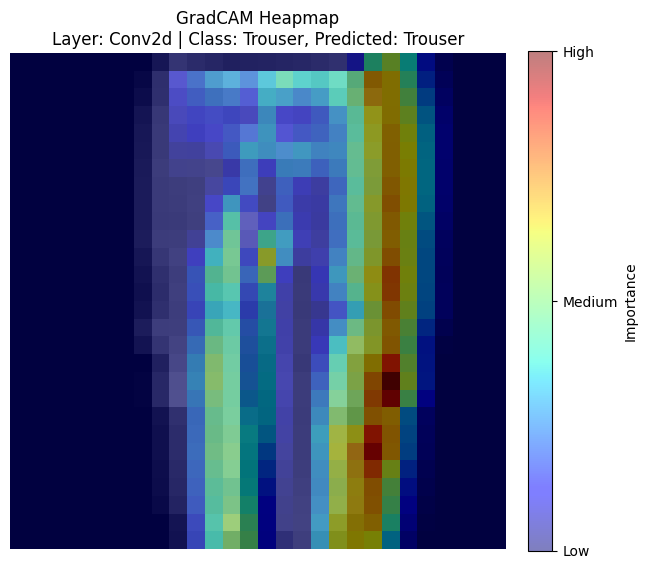

```python
# Get an image from dataloader
data = next(iter(train_loader))
image = data[0][0].unsqueeze(0)
label = data[1][0].item()

# Plot it on the GradCAM
plot_gradcam(basic_model, image, label, [basic_model.conv1])
```

- Since this is a basic CNN with only one convolutional layer, the model is performing much of the **low-level** feature extraction such as edges, lines and corners
- However, due to the lack of depth of more conv layers, its unable to have deeper focus in particular areas, making it harder to grasp complex patterns, which explains its lower accuracy

## Deeper CNN Model: Enhancing Feature Extraction

- The purpose of developing this model is to address the limitations of the Basic CNN, particularly its inability to further improve accuracy after the initial gains in training.
- One of the key observations from the confusion matrix was that the Basic CNN struggled to **accurately classify certain classes**, most notably the **Shirt** category.
  - This difficulty is likely due to the Basic CNN's limited capacity:
    - It only includes a **single convolutional layer** with **few channels**, which restricts its ability to learn and extract **more complex patterns**.
      - As a result, it fails to capture the **subtle differences** between visually similar classes, such as Shirts, T-Shirts and Coats.

### Purpose of the Deeper CNN:

- To **expand the model's capacity** by introducing **deeper** and **denser convolutional layers** (i.e., more layers with more channels).
- This allows the model to **extract more complex and higher-level features**, improving its ability to distinguish between **fine-grained differences** in images.

```python
class DeeperCNN(nn.Module):
    def __init__(self, input_shape=(1, 28, 28), num_classes=10):
        super(DeeperCNN, self).__init__()

        # Layer 1
        self.conv1_1 = nn.Conv2d(1, 32, kernel_size=3, padding=1)
        self.conv1_2 = nn.Conv2d(32, 32, kernel_size=3, padding=1)
        self.pool = nn.MaxPool2d(2, 2)

        # Layer 2
        self.conv2_1 = nn.Conv2d(32, 64, kernel_size=3, padding=1)
        self.conv2_2 = nn.Conv2d(64, 64, kernel_size=3, padding=1)

        self.flattened_size = self._get_flattened_size(input_shape)

        # Fully connected Layers
        self.fc1 = nn.Linear(self.flattened_size, 64)
        self.fc2 = nn.Linear(64, num_classes)

    def _get_flattened_size(self, input_shape):
        with torch.no_grad():
            x = torch.zeros(1, *input_shape)

            # Layer 1
            x = F.relu(self.conv1_1(x))
            x = F.relu(self.conv1_2(x))
            x = self.pool(x)

            # Layer 2
            x = F.relu(self.conv2_1(x))
            x = F.relu(self.conv2_2(x))
            x = self.pool(x)

            return x.numel()

    def forward(self, x):
        # Layer 1
        x = F.relu(self.conv1_1(x))
        x = F.relu(self.conv1_2(x))
        x = self.pool(x)

        # Layer 2
        x = F.relu(self.conv2_1(x))
        x = F.relu(self.conv2_2(x))
        x = self.pool(x)

        # Flatten
        x = x.view(x.size(0), -1)

        # Fully connected Layers
        x = F.relu(self.fc1(x))
        x = self.fc2(x)

        return x

deeper_model = DeeperCNN().to(device)
print(deeper_model)
```

```
DeeperCNN(
  (conv1_1): Conv2d(1, 32, kernel_size=(3, 3), stride=(1, 1), padding=(1, 1))
  (conv1_2): Conv2d(32, 32, kernel_size=(3, 3), stride=(1, 1), padding=(1, 1))
  (pool): MaxPool2d(kernel_size=2, stride=2, padding=0, dilation=1, ceil_mode=False)
  (conv2_1): Conv2d(32, 64, kernel_size=(3, 3), stride=(1, 1), padding=(1, 1))
  (conv2_2): Conv2d(64, 64, kernel_size=(3, 3), stride=(1, 1), padding=(1, 1))
  (fc1): Linear(in_features=3136, out_features=64, bias=True)
  (fc2): Linear(in_features=64, out_features=10, bias=True)
)
```

We can then do as before and prepare our learning rate, optimizer and loss function

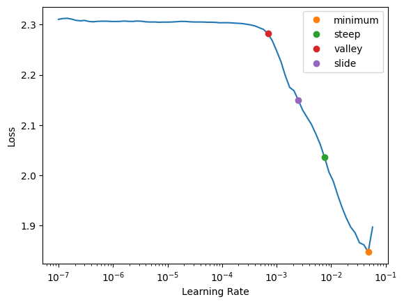

```python
num_epochs = 100 # Same epochs (with Early Stopping)

lr, _ = find_lr(deeper_model, optimizer_class=optim.Adam) # Find learning rate

optimizer = optim.Adam(deeper_model.parameters(), lr=lr) # Use learning rate on Adam Optimizer

loss_fn = nn.CrossEntropyLoss() # Same loss as before
```

```python
deeper_metrics = train_model(deeper_model, train_loader, val_loader, loss_fn, optimizer, None, num_epochs)
```

```
Epoch duration: 17.59 seconds
Epoch duration: 18.02 seconds
Epoch duration: 19.12 seconds
Epoch duration: 18.34 seconds
Epoch duration: 17.56 seconds
No improvement in val_loss for 1 epoch(s)
Epoch duration: 18.13 seconds
Epoch duration: 17.52 seconds
No improvement in val_loss for 1 epoch(s)
Epoch duration: 18.05 seconds
No improvement in val_loss for 2 epoch(s)
Epoch duration: 17.78 seconds
No improvement in val_loss for 3 epoch(s)
Epoch duration: 18.23 seconds
No improvement in val_loss for 4 epoch(s)
Epoch duration: 17.79 seconds
No improvement in val_loss for 5 epoch(s)
Stopping at epoch 11
Total Duration: 198.11 seconds
```

### Evaluating the Loss and Accuracy of our Deeper Model

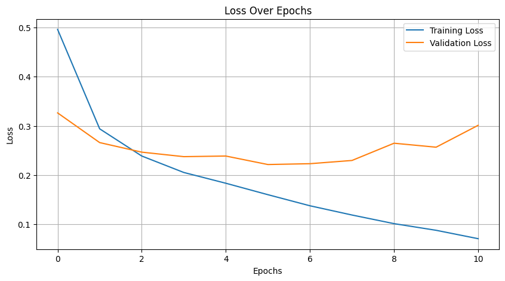

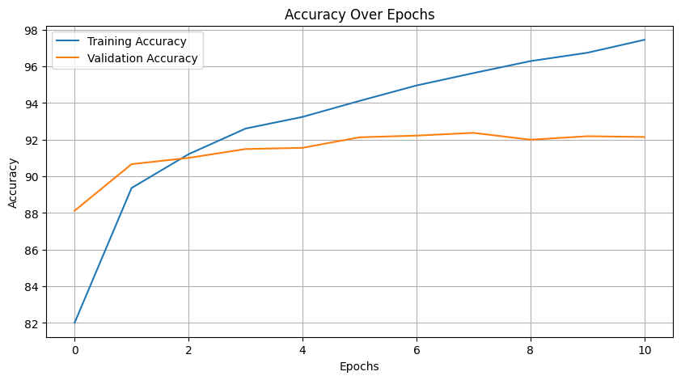

```python
# Plot losses
plot_metric(deeper_metrics.train.losses, deeper_metrics.val.losses, metric_name="Loss")

# Plot accuracies
plot_metric(deeper_metrics.train.accuracies, deeper_metrics.val.accuracies, metric_name="Accuracy")
```

```python
deeper_test_accuracy, deeper_predictions = evaluate_model(deeper_model, test_loader)
print(f"Accuracy on Test Set: {deeper_test_accuracy:.2f}%")
```

```
Accuracy on Test Set: 92.11%
```

### Training

- Training convergance is much quicker, reaching a higher final training accuracy

### Validation

- Shows simillar levels of overfitting still
- Will be discussed in the final model

### Visualizing Confusion Matrix (Deeper)

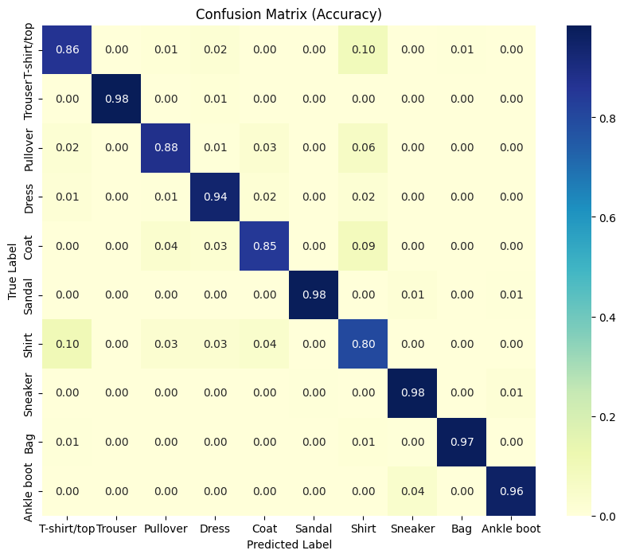

```python
plot_confusion_matrix(deeper_predictions)
```

- Comparing this martrix with the result from the basic model, it is clear that the Deeper model is more capable of classifying Shirts compared to the Basic Model
- However, certain classifications such as Shirt and T-Shirt, before worse in some training results, possibly indicating some overfitting that is occuring

### Visualizing GradCAM (Deeper)

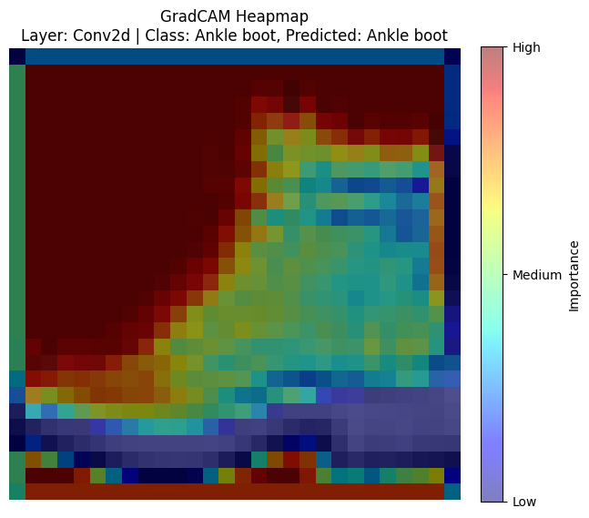

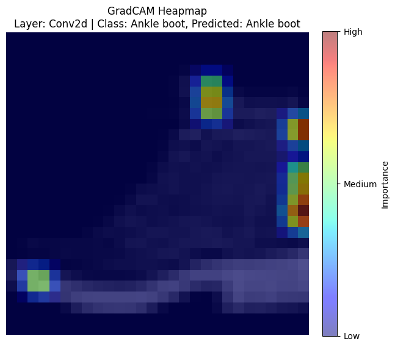

```python
data = next(iter(train_loader))
image = data[0][0].unsqueeze(0)
label = data[1][0].item()

# Pass a list of layers now we have move
plot_gradcam(deeper_model, image, label, [deeper_model.conv1_1, deeper_model.conv2_1])
```

- From our GradCAM observation, it is aparrant that each of our conv models is responsible for focusing on a particular area of the image such as edges, corners etc.
- Furthermore, it also can be seen that other conv layers are hyperfocusing in particular areas, denoting the models observance to complex patterns and designs in the image.

## The Advanced CNN: Optimizing Hyperparameters, Avoiding Overfitting, and Putting Everything togehter

- The final model of this notebook is shown below: It encompasses all of what is discussed above, along with additional techniques for more robust training, and reduced overfitting: [17]
- To achieve this, I have added several key components and regularization techniques including:
  - **Batch Normalization** (`BatchNorm2d`):
    - Normalizes inputs from the previous layer above (in our case, the conv layer)
      - Helps stabilize training by reducing the shifts in distributions
  - **Dropout** (`Dropout`):
    - Randomly turns off a percentage of neurons in the network with a certain proability `p`
    - Forces the network to not heavily rely on specific neurons, which reduces overfitting
  - **Global Average Pooling** (`AdaptiveAvgPool2d`):
    - Reduces the size of the feature map (simillar concept to `MaxPool2d`)
      - - It produces a **single number** for each feature map, summarizing the presence of that feature over the entire spatial dimension.

Also, due to the immense size increase of this mode compared to the Deeper CNN as a result of more layers, with additional regularization techniques, I have decided to change the format of the model to use `nn.Sequential`, but it functions completely the same. `nn.Sequential` instead organizes of of the components into its own layer and performs each sequentially when using this layer in the forward pass

- The idea for having multiple Conv layers in one compound layer was inspired from a study I found [22] comparing different models performance metrics when training on the FashionMNIST Dataset
- It showed that having deeper networks of multiple convolutional layers was beneficial at classifying some of the complex patterns present in the FashionMNIST Dataset
- The model that performed the best was the MCNN15 with a ~94% accuracy, which included these duplicate set of conv layers per compound layer
  - However, despite it not including the most conv layers compared to others such as the MCNN18, it still had a greater final accuracy, implying that simply adding more and more layers to the CNN isn't necessarily going to give it better performance, and the balance needs to be found through hyperparameter tuning
- Furthermore, the idea for including batch normalization and max pooling, with occasional dropout in each of these layers as well was inspired by this Tutorial [13], which also had a very high performing accuracy, so I decided to experiment with these ideas and aim to achieve a simillar, or better result
- For the learning of Dropout and other regularization techniques, I used another YouTube video made by Greg Hogg [21]

```python
class AdvancedCNN(nn.Module):
    def __init__(self, num_classes=10):
        super().__init__()
        # Layer 1: Two Convolutional Layers (1 -> 64 -> 64)
        self.layer1 = nn.Sequential(
            nn.Conv2d(1, 64, kernel_size=3, padding=1),
            nn.ReLU(),
            nn.BatchNorm2d(64),
            nn.Conv2d(64, 64, kernel_size=3, padding=1),
            nn.ReLU(),
            nn.BatchNorm2d(64),
            nn.MaxPool2d(2),
            nn.Dropout(0.2)
        )

        # Layer 2: Two Convolutional Layers (64 -> 128 -> 128)
        self.layer2 = nn.Sequential(
            nn.Conv2d(64, 128, kernel_size=3, padding=1),
            nn.ReLU(),
            nn.BatchNorm2d(128),
            nn.Conv2d(128, 128, kernel_size=3, padding=1),
            nn.ReLU(),
            nn.BatchNorm2d(128),
            nn.MaxPool2d(2),
            nn.Dropout(0.25)
        )

        # Layer 3: Two Convolutional Layers (128 -> 256 -> 256)
        self.layer3 = nn.Sequential(
            nn.Conv2d(128, 256, kernel_size=3, padding=1),
            nn.ReLU(),
            nn.BatchNorm2d(256),
            nn.Conv2d(256, 256, kernel_size=3, padding=1),
            nn.ReLU(),
            nn.BatchNorm2d(256),
            nn.AdaptiveAvgPool2d(1),
            nn.Dropout(0.3)
        )

        # Fully Connected Layer: Classifier
        self.fc = nn.Sequential(
            nn.Flatten(),
            nn.Linear(256, 128),
            nn.ReLU(),
            nn.Dropout(0.5),
            nn.Linear(128, num_classes)
        )

    def forward(self, x):
        x = self.layer1(x)
        x = self.layer2(x)
        x = self.layer3(x)
        x = self.fc(x)
        return x

advanced_model = AdvancedCNN().to(device)
print(advanced_model)
```

```
AdvancedCNN(
  (layer1): Sequential(
    (0): Conv2d(1, 64, kernel_size=(3, 3), stride=(1, 1), padding=(1, 1))
    (1): ReLU()
    (2): BatchNorm2d(64, eps=1e-05, momentum=0.1, affine=True, track_running_stats=True)
    (3): Conv2d(64, 64, kernel_size=(3, 3), stride=(1, 1), padding=(1, 1))
    (4): ReLU()
    (5): BatchNorm2d(64, eps=1e-05, momentum=0.1, affine=True, track_running_stats=True)
    (6): MaxPool2d(kernel_size=2, stride=2, padding=0, dilation=1, ceil_mode=False)
    (7): Dropout(p=0.2, inplace=False)
  )
  (layer2): Sequential(
    (0): Conv2d(64, 128, kernel_size=(3, 3), stride=(1, 1), padding=(1, 1))
    (1): ReLU()
    (2): BatchNorm2d(128, eps=1e-05, momentum=0.1, affine=True, track_running_stats=True)
    (3): Conv2d(128, 128, kernel_size=(3, 3), stride=(1, 1), padding=(1, 1))
    (4): ReLU()
    (5): BatchNorm2d(128, eps=1e-05, momentum=0.1, affine=True, track_running_stats=True)
    (6): MaxPool2d(kernel_size=2, stride=2, padding=0, dilation=1, ceil_mode=False)
    (7): Dropout(p=0.25, inplace=False)
  )
  (layer3): Sequential(
    (0): Conv2d(128, 256, kernel_size=(3, 3), stride=(1, 1), padding=(1, 1))
    (1): ReLU()
    (2): BatchNorm2d(256, eps=1e-05, momentum=0.1, affine=True, track_running_stats=True)
    (3): Conv2d(256, 256, kernel_size=(3, 3), stride=(1, 1), padding=(1, 1))
    (4): ReLU()
    (5): BatchNorm2d(256, eps=1e-05, momentum=0.1, affine=True, track_running_stats=True)
    (6): AdaptiveAvgPool2d(output_size=1)
    (7): Dropout(p=0.3, inplace=False)
  )
  (fc): Sequential(
    (0): Flatten(start_dim=1, end_dim=-1)
    (1): Linear(in_features=256, out_features=128, bias=True)
    (2): ReLU()
    (3): Dropout(p=0.5, inplace=False)
    (4): Linear(in_features=128, out_features=10, bias=True)
  )
)
```

### Data Augmentation

- Through this tutorial [12], I noticed that one of their conclusions was that adding data augmentations such as rotations, colour jittering, and cropping to the training set, prevented overfitting
- So I have decided to implement it in my Advanced Model
- To do this:
  - The transform object has to be redefined to include all the necessary modifications, along with the previous ones
  - We keep the validation and test dataset transforms as before, as we dont want to modify those with data augmentation
  - We then load both datasets, and use `Subset` to split the train and val dataset using the same `train_val_dataset` whilst having different transofmrations for both
  - We also need to redefine the `DataLoaders` collection for FastAI's learning rate finder to work on the new data loaders
- I use the same data augmentation as shown in this tutorial here [12] as it provided very high success with my model, though this could be easily modified with different image modifications to observe performance differences

```python
transform = transforms.Compose([
    transforms.RandomHorizontalFlip(p=0.5), # Randomly flip image horizontally with 50% probability
    transforms.RandomVerticalFlip(p=0.2), # Randomly flip image vertically with 20% probability
    transforms.RandomResizedCrop((28,28), scale=(0.8, 1.0), ratio=(0.75, 1.25)), # Randomly crop and resize the image to 28x28 with scaling and aspect ratio variation
    transforms.ColorJitter(brightness=[0.8,1], contrast=[0.8,1], saturation=0, hue=0), # Randomly adjust brightness and contrast
    transforms.ToTensor(),
    transforms.Normalize((mean,), (std,))
])

# Test (and Validation) should not include data augmentation
test_transform = transforms.Compose([
    transforms.ToTensor(),
    transforms.Normalize((mean,), (std,)),
])

train_val_dataset = datasets.FashionMNIST(root="./data", train=True, transform=transform, download=True)
test_dataset = datasets.FashionMNIST(root="./data", train=False, transform=transform, download=True)

# Create indices for the split
train_size = int(0.8 * len(train_val_dataset))
val_size = len(train_val_dataset) - train_size
train_indices, val_indices = torch.utils.data.random_split(range(len(train_val_dataset)), [train_size, val_size])

# Create two separate datasets for train and val, with different transforms
train_dataset = datasets.FashionMNIST(root="./data", train=True, transform=transform, download=True)
val_dataset = datasets.FashionMNIST(root="./data", train=True, transform=test_transform, download=True)

# Test already has its own with train = False
test_dataset = datasets.FashionMNIST(root="./data", train=False, transform=test_transform, download=True)

# Use the indicies to create a Subset through each dataset
train_dataset = Subset(train_dataset, train_indices)
val_dataset = Subset(val_dataset, val_indices)

train_loader = DataLoader(train_dataset, batch_size=batch_size, num_workers=4, shuffle=True)
val_loader = DataLoader(val_dataset, batch_size=batch_size, num_workers=4, shuffle=False)
test_loader = DataLoader(test_dataset, batch_size=batch_size, num_workers=4, shuffle=False)

print(f"Training samples: {len(train_dataset)}")
print(f"Validation samples: {len(val_dataset)}")
print(f"Test samples: {len(test_dataset)}")
print(f"Training batches: {len(train_loader)}")
print(f"Validation batches: {len(val_loader)}")
print(f"Test samples: {len(val_loader)}")

# Redefine DataLoaders collection for learning rate finder
dls = DataLoaders(train_loader, val_loader)
```

```
Training samples: 48000
Validation samples: 12000
Test samples: 10000
Training batches: 750
Validation batches: 188
Test samples: 188
```

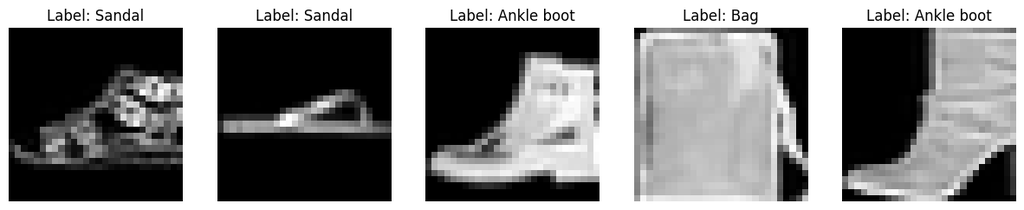

```python
images, labels = zip(*[train_dataset[i] for i in range(5)])

fig, axes = plt.subplots(1, 5, figsize=(15, 3))

for i, ax in enumerate(axes):
    image = denormalize(images[i].squeeze())

    ax.imshow(image.numpy(), cmap='gray')
    ax.set_title(f"Label: {class_names[labels[i]]}")
    ax.axis('off')

plt.show()
```

### Optimizing the Optimizer

- Due to the Advanced Models drastic increase in complexity, we will be able to take advantages of the bonuses of SGD, provided we can optimize the hyperparameters for this model
- Although the Adam Optimizer is very good at reaching a solid convergance quickly, it suffers with overfitting
- SGD on other other hand, has the capability to outperform Adam and other optimizers and have less overfitting overall, but requires significnatly more fine tuning and optimization to get the best results out of it
- For this reason, I have decided to use the SGD optimizer for this model, where I will define additional hyperparameters and aim to find the best values for the optimizer
  - I will also be using a learning rate adjustment techniques known as **Scheduling**, which generally, starts the learning rate off high, ao allow the model to expore more of the loss landscape, and decays as the model reaches convergance, allowing it to reach the optimal minima
    - I will be using **Cosine Annealing** for this as it goes well with SGD

SGD requires an attribute known as momentum, which "pushes" SGD in the right direction, preventing it from getting "stuck"

```python
momentum = 0.9
```

```python
weight_decay = 1e-4
```

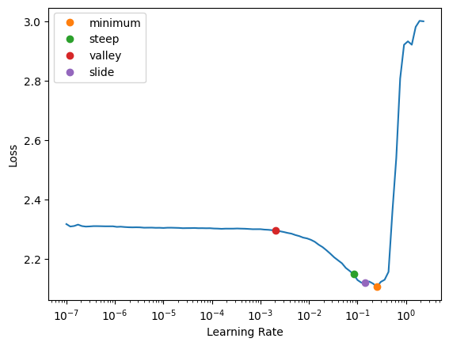

```python
num_epochs = 100 # Stick to 100 epochs

lr_min, lr_max = find_lr(
    advanced_model,
    optimizer_class=optim.SGD,
    opt_kwargs={
        'momentum': momentum,
        'weight_decay': weight_decay,
        'nesterov': True
    }
)

optimizer = torch.optim.SGD(
    advanced_model.parameters(),
    momentum = momentum, # Add momentum to return direction
    nesterov = True, # Accelerated gradients (Can help optimize SGD)
    weight_decay = weight_decay, # Add weight decay to help reduce overfitting
    lr=lr_max # Start at the max leraning rate
)

loss_fn = nn.CrossEntropyLoss()
```

### The Scheduler

- As discussed above, I will be using **Cosine Annealing** as the scheduler of my choice for this model

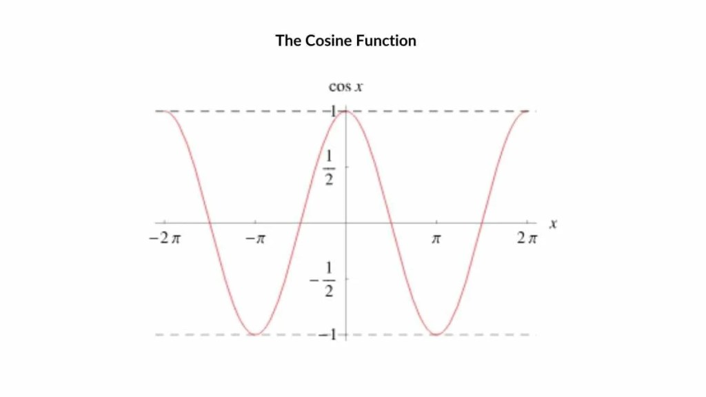

- This model works in a simillar way of other Scheduler by decreasing the learning rate over time, but instead of doing a fixed decay, it instead dynamically reduces the learning rate over each epoch using the cosine graph, leading to often better convergance and generalization [10]

The formula for the Cosine Annealing Scheduler is: $$ \eta_t = \eta_{\text{min}} + \frac{1}{2} (\eta_{\text{max}} - \eta_{\text{min}}) \left( 1 + \cos \left( \frac{T_{\text{cur}}}{T_{\text{max}}} \pi \right) \right) $$

**Where:**

- **$\eta_t$** : The learning rate at time step *t* (current iteration or epoch).
- **$\eta_{\text{min}}$** : The minimum learning rate (the lower bound for the learning rate during annealing).
- **$\eta_{\text{max}}$** : The maximum learning rate (the starting or peak learning rate for the cycle).
- **$T_{\text{cur}}$** : The current time step or epoch within the current cycle.
- **$T_{\text{max}}$** : The maximum number of iterations or epochs in the current cycle (defines the length of one cosine cycle).

Plugging this formula into GeoGebra [11], we get the following graph shape:

- x-axis is the Epochs
- y-axis is the Learning Rate

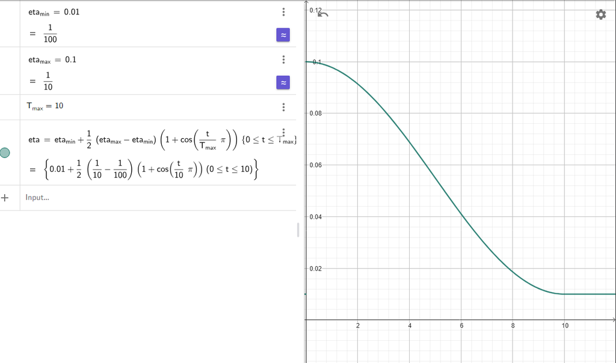

- **Starts high** → promotes **exploration** between difference maximas
- **Decays smoothly** → faster in the middle
- **Ends low** → allows for **fine-tuning** and convergence

```python
# Learning rate periodically decays to lr_min
scheduler = torch.optim.lr_scheduler.CosineAnnealingLR(
    optimizer, # Pass the optimizer so it can adjust its learning rate
    T_max=num_epochs, # Lasts for the entire training cycle
    eta_min=lr_min # Decays to lr_min
)
```

- Due to the adjusting nature of the learning rate in Cosine Annealing, the model can sometimes appear to be stuck at a suboptimal point in training.
- However, as the learning rate continues to decrease or cycles through its schedule the model often escapes these plateaus and progresses towards better solutions.
- Using early stopping in this scenario could prematurely halt training before the learning rate has a chance to properly adjust and allow the model to converge.
- For this reason, I chose to remove early stopping to let the scheduler complete its intended learning rate cycle and give the model the opportunity to fully benefit from the Cosine Annealing schedule

```python
advanced_metrics = train_model(advanced_model, train_loader, val_loader, loss_fn, optimizer, scheduler, num_epochs, False)
```

```
Epoch duration: 37.25 seconds
Epoch duration: 37.58 seconds
Epoch duration: 38.53 seconds
Epoch duration: 36.94 seconds
Epoch duration: 37.27 seconds
Epoch duration: 37.28 seconds
Epoch duration: 37.12 seconds
Epoch duration: 36.37 seconds
Epoch duration: 37.67 seconds
Epoch duration: 37.45 seconds
Epoch duration: 37.66 seconds
Epoch duration: 36.25 seconds
Epoch duration: 36.25 seconds
Epoch duration: 36.27 seconds
Epoch duration: 36.11 seconds
Epoch duration: 35.70 seconds
Epoch duration: 36.07 seconds
Epoch duration: 37.53 seconds
Epoch duration: 37.37 seconds
Epoch duration: 37.29 seconds
Epoch duration: 36.99 seconds
Epoch duration: 36.51 seconds
Epoch duration: 36.68 seconds
Epoch duration: 36.52 seconds
Epoch duration: 37.41 seconds
Epoch duration: 35.47 seconds
Epoch duration: 36.13 seconds
Epoch duration: 36.15 seconds
Epoch duration: 36.46 seconds
Epoch duration: 36.24 seconds
Epoch duration: 36.31 seconds
Epoch duration: 35.15 seconds
Epoch duration: 37.42 seconds
Epoch duration: 36.39 seconds
Epoch duration: 36.57 seconds
Epoch duration: 36.48 seconds
Epoch duration: 36.01 seconds
Epoch duration: 35.77 seconds
Epoch duration: 35.47 seconds
Epoch duration: 37.53 seconds
```

[output cut: 46 more lines]

```
Epoch duration: 35.79 seconds
Epoch duration: 35.79 seconds
Epoch duration: 35.73 seconds
Epoch duration: 35.51 seconds
Epoch duration: 34.90 seconds
Epoch duration: 37.01 seconds
Epoch duration: 35.83 seconds
Epoch duration: 36.37 seconds
Epoch duration: 35.40 seconds
Epoch duration: 34.77 seconds
Epoch duration: 35.49 seconds
Epoch duration: 35.42 seconds
Epoch duration: 36.60 seconds
Epoch duration: 35.85 seconds
Total Duration: 3638.19 seconds
```

Through the training process of 100 epochs, this model managed to achieve a higher validation accuracy with much less signs of overfitting

```python
advanced_test_accuracy, advanced_predictions = evaluate_model(advanced_model, test_loader)
print(f"Accuracy on Test Set: {advanced_test_accuracy:.2f}%")
```

```
Accuracy on Test Set: 94.28%
```

### Evaluating the Loss and Accuracy of our Advanced Model

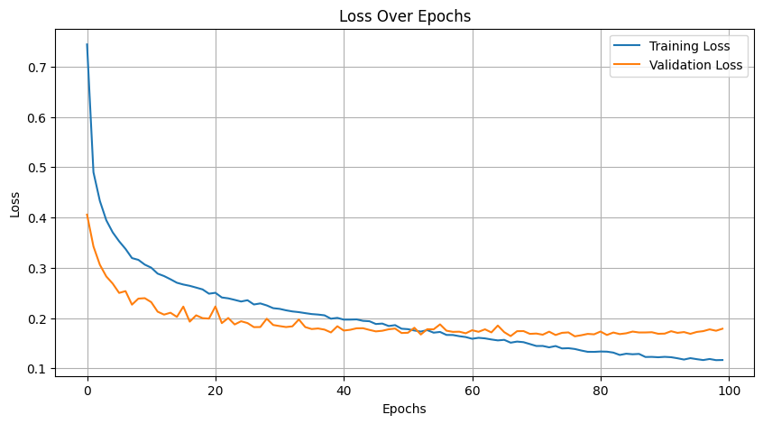

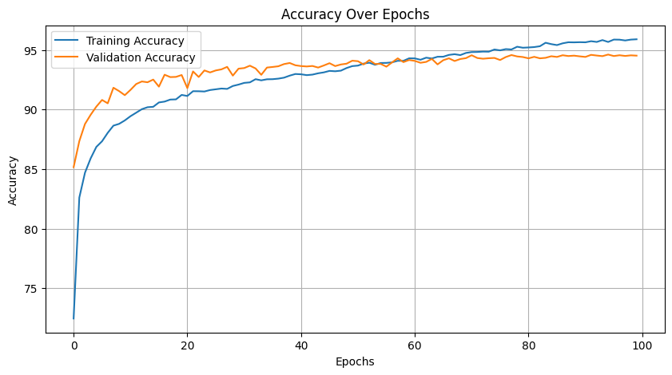

```python
# Plot losses
plot_metric(advanced_metrics.train.losses, advanced_metrics.val.losses, metric_name="Loss")

# Plot accuracies
plot_metric(advanced_metrics.train.accuracies, advanced_metrics.val.accuracies, metric_name="Accuracy")
```

#### Training

- Thanks to the Scheduler we used, our model managed to have a steep decline in loss from the get go as a result of the higher learning rate
- This decline gradient steadily decreases after this due to the learning rate decay, and continues working its way to a >95% training accuracy

### Visualizing Confusion Matrix (Advanced)

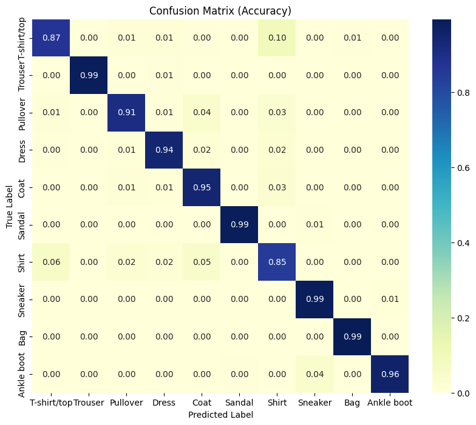

```python
plot_confusion_matrix(advanced_predictions)
```

As shown from the final models confusion matrix, it performs even better at classifying shirts than both models, having less misclassifications overall in the shirt category, and in general with other labels

### Visualizing GradCAM (Advanced)

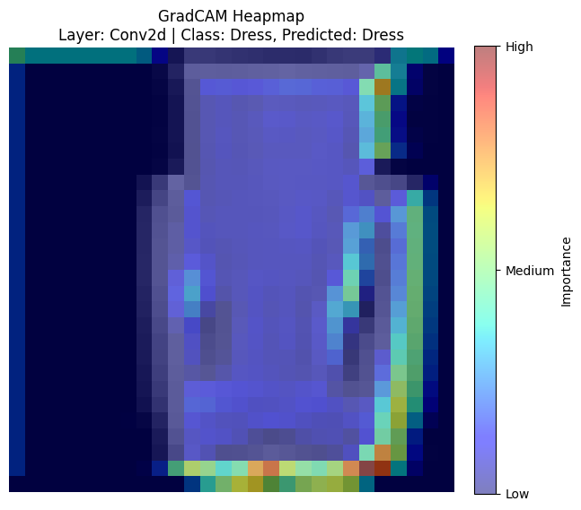

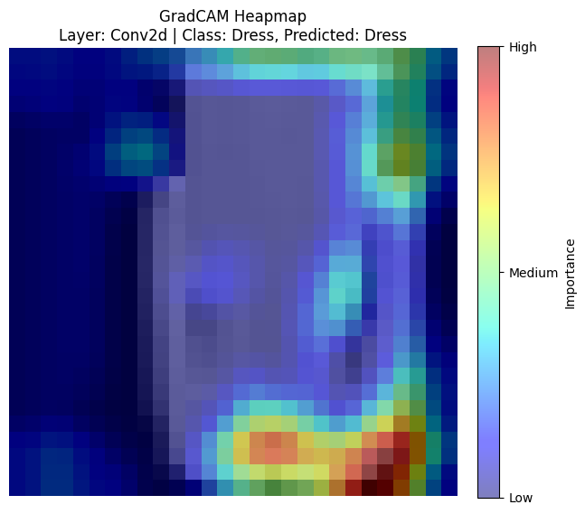

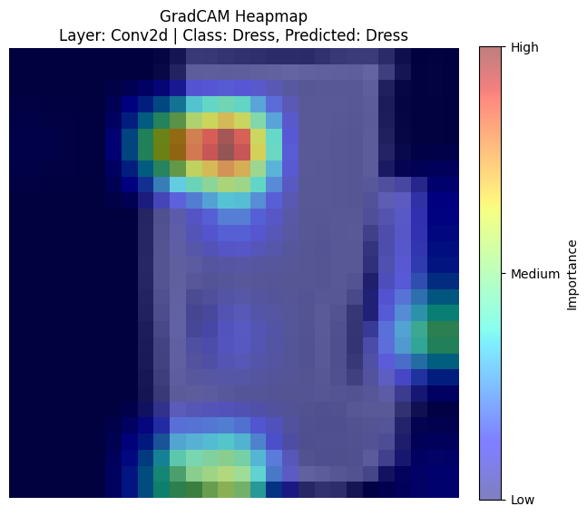

```python
data = next(iter(train_loader))
image = data[0][0].unsqueeze(0)
label = data[1][0].item()

target_layers = [
    advanced_model.layer1[0],
    advanced_model.layer2[0],
    advanced_model.layer3[0]
]

plot_gradcam(advanced_model, image, label, target_layers)
```

## Comparing the metrics of each of my Models

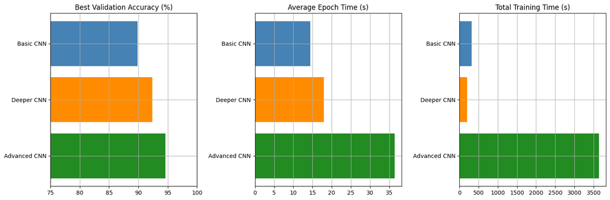

```python
metrics = [basic_metrics, deeper_metrics, advanced_metrics]
best_accuracies = [m.val.best_accuracy for m in metrics]
average_epoch_times = [np.mean(m.time.epochs) for m in metrics]
total_durations = [m.time.total for m in metrics]

models = ['Basic CNN', 'Deeper CNN', 'Advanced CNN']

fig, axs = plt.subplots(1, 3, figsize=(15, 5))  # 1 row, 3 columns of plots
y_pos = np.arange(len(models))  # [0, 1, 2]

titles = ['Best Validation Accuracy (%)', 'Average Epoch Time (s)', 'Total Training Time (s)']
colors = ['steelblue', 'darkorange', 'forestgreen']  # One color for each model
data = [best_accuracies, average_epoch_times, total_durations]

# loop over the axes, titles, and data at once
for ax, title, d in zip(axs, titles, data):
    ax.barh(y_pos, d, color=colors)  # Horizontal bar plot, consistent model colors across all charts

    # Where to set the line on the Y-axis
    ax.set_yticks(y_pos)
    ax.set_yticklabels(models)

    ax.invert_yaxis()  # Invert axis to match your image order
    ax.set_title(title)
    ax.grid(True)

    # Set x-axis from 75% to 100% for easier comparison
    if title == 'Best Validation Accuracy (%)':
        ax.set_xlim(75, 100)

fig.tight_layout()
plt.show()
```

What can be seen from these results is

- The Advanced Model outperforms both the other models in accuracy
- But the Advanced model takes significantly longer to complete each epoch due to its greater number of layers and density
- Also, the advanced model takes significantly longer to converge, as it requires the full 100 epochs to reach final convergence, with minimal overtraining

So, our Advanced Model has made significant improvement from our previous ones, but these gains comes with some trade-offs that need to be considered when designing a CNN

## Conclusion

- The FashionMNIST dataset, as observed from mine, and other tutorials online, is significantly more difficult to reach the higher end of validation accuracies than other simpler datasets such as the MNIST and require much more fine tuning.
- Many of the tutorials I found online were between 87% and 95% validation accuracy, with most being on the mid to lower end of this
  - The tutorials that managed to reach a higher validation accuracy than this were often vastly more complicated with deeper and denser layers that would take significantly longer to train on
- My final model achieved ~**94.5%** validation accuracy, placing it at the **upper end** of the range commonly found in similar work.
  - This demonstrates that the model was able to perform **competitively**, without excessive architectural complexity or unreasonably long training times.
- Overall, this shows that with a well-balanced combination of **depth**, **regularization techniques** (such as **Dropout**, **Batch Normalization**, and **Global Average Pooling**), and **proper tuning of hyperparameters**, it’s possible to build an **efficient** and **high-performing** CNN for the FashionMNIST dataset.

## References

[1] https://medium.com/@khwabkalra1/convolutional-neural-networks-for-image-classification-f0754f7b94aa  
[2] https://www.youtube.com/watch?v=H69j69FFMV0  
[3] https://poloclub.github.io/cnn-explainer/  
[4] https://www.geeksforgeeks.org/how-to-handle-overfitting-in-pytorch-models-using-early-stopping/  
[5] https://github.com/m2dsupsdlclass/lectures-labs/blob/master/labs/08_frameworks/Fashion_MNIST_classification.ipynb  
[6] https://medium.com/analytics-vidhya/the-learning-rate-finder-9203fdc67c92  
[7] https://www.jeremyjordan.me/nn-learning-rate/  
[8] https://docs.fast.ai/examples/app_examples.html#keypoints  
[9] https://fastai1.fast.ai/callbacks.lr_finder.html  
[10] https://spotintelligence.com/2024/04/29/cosine-annealing-in-machine-learning/  
[11] https://www.geogebra.org/  
[12] https://github.com/RoshanRane/Deep-learning-with-Pytorch-and-FashionMNIST/blob/master/Fashion_MNIST_Rane.ipynb  
[13] https://pyimagesearch.com/2019/02/11/fashion-mnist-with-keras-and-deep-learning/  
[14] https://www.reddit.com/r/MLQuestions/comments/b6wk5y/how_can_i_improve_the_accuracy_of_my_cnn_on/  
[15] https://colab.research.google.com/drive/1mDzUl4Fp9QkhPPjN817gNKAUEhiY8kpt?usp=sharing#scrollTo=XLFPG1sjmOdI  
[16] https://github.com/m2dsupsdlclass/lectures-labs/blob/master/labs/08_frameworks/Fashion_MNIST_classification.ipynb  
[17] https://stackoverflow.com/questions/36139980/prevention-of-overfitting-in-convolutional-layers-of-a-cnn  
[18] https://pytorch.org/vision/stable/generated/torchvision.datasets.FashionMNIST.html  
[19] https://www.geeksforgeeks.org/how-should-the-learning-rate-change-as-the-batch-size-changes/  
[20] https://github.com/jacobgil/pytorch-grad-cam/blob/master/tutorials/CAM%20Metrics%20And%20Tuning%20Tutorial.ipynb  
[21] https://www.youtube.com/watch?v=xP9l9MptIZo  
[22] https://www.researchgate.net/publication/366072977_Image_Classification_Using_Multiple_Convolutional_Neural_Networks_on_the_Fashion-MNIST_Dataset